# Notes1 - Statistical Inference

Linda Kukolich

February 4, 2015

Lecturer: Brian Caffo

These are new lectures with hand written text on them. Pretty, but not the lecture notes from last time. Also more interesting, so far. I will be taking notes, as usual, rather than trying to work from the old notes that are posted. I am basing my notes on the subtitle transcript.

# 1- Introduction

## Statistical Inference Defined

> Generating conclusions about a population from a noisy sample
- Without statistical inference, simply living within our data
- With statistical inference, we’re trying to generate new knowledge
  - extend beyond our data to a population to get answers
  - estimators have actual things they are estimating
- Statistical inference is the only formal system of inference we have

## Examples

1. Who will win an election on Election Day based on a sample of likely voters taken today?
   - our sample is a noisy data set.
   - Some people might not actually vote on Election Day,
   - some people might change their mind as to what they’re going to say now, or
   - some people might even be deliberately misleading.
   - We’d like to try to draw together all that uncertainly, and use that to predict who’s going to win on Election Day.
2. What is the probability it will rain tomorrow?
   - they’re trying to use the historical data
   - and particularly the most recent data
   - to predict tomorrow’s weather
   - and actually attach a probability to it.
3. What brain regions will light up in an fMRI scanner?
   - Scan people doing a task (tapping fingers)
   - compare +finger-tapping to -finger-tapping
   - figure out what brain regions are associated with finger tapping
- Statistical Inference is Challenging
- Models of randomness are key

## Frequentist Versus Bayesian

- More divides than just that Frequentist versus Bayesian
  - among frequentists
  - among Bayesians
- Choosing frequentist
  - most commonly taught
  - most likely that we are familiar with this
  - most likely that we will work with in future

## Frequentist Thinking

- Probability is like gambling
  - flip a coin an infinite number of times
  - the proportion of heads is the probability of heads
    - $\hat{p} = p$
  - we can repeat the experiment over and over

## Uses of Statistical Inference

- Infer causation (not just association) from noisy statistical data
  - Does smoking cause cancer?
  - Does an ad campaign cause an increase in web traffic?
  - Does a new treatment really return a reduction in cancer progress?
- Requirements enumeration of
  - assumptions
  - set of tools
  - statistical study designs
- Requires us to define what we mean by something causing something else

## Welcome

- this is deep stuff and unusual
  - 4 week course
  - okay to take it twice if it is too hard
- grading
  - 4 homework sets
    - On github
    - harder than quizzes
    - linked to quiz questions
  - 4 quizzes
  - 1 project
    - Think long about project
    - sampling distributions
    - frequency stle statistical inference
- This is Caffo’s favorite subject
- He has studied it for 15 years
- He continues to learn new things about it

## Reference Page

- There is a glossary of terms for each week of the class

# 2- Introduction to Probability

- This is a light introduction
- Deeper intro in Bio-stats Bootcamp

## probability

- Given a random experiment (say rolling a die) a probability measure is a **population** quantity that summarizes the randomness
  - The probability is a fixed property of the die
  - Not a simple set of fixed rolls of the die
- Probability takes a possible outcome from the experiment and:
  - assigns it a number of 0 and 1
  - the probability of the union of all possible outcomes is 1 (add all the probabilities)
- Rules
  - The probability that nothing happens is 0
  - The probability that something happens is 1
  - The probability of something is 1 minus the probability of its opposite
  - The probability of at least one of two or more things that cannot simultaneously occur (mutually exclusive), is the sum of their respective probabilities.
  - If the event A implies the occurrence of the event B, then the probability of A occurring is less than the probability that B occurs. (If A is inside B, it can be no larger than B)
  - For any two events, the probability that at least one occurs is the sum of their probabilities minus their intersection. (If part of A covers part of B, then the area of both is A + B - the part where they overlap)

## Example

The National Sleep Foundation reports that around 3% of the American population has sleep apnea. They also report around 10% of the North American and European population has restless leg syndrome. *Let’s assume, for the sake of argument, that these are probabilities from the same population.* Can we just simply add these probabilities, and conclude that about 13% of people have at least one sleep problem of these sorts in this population?

$\begin{eqnarray*} A_1 & = & \{\mbox{Person has sleep apnea}\} \\ A_2 & = & \{\mbox{Person has RLS}\} \end{eqnarray*}$ Then

$\begin{eqnarray*} P(A_1 \cup A_2 ) & = & P(A_1) + P(A_2) - P(A_1 \cap A_2) \\ & = & 0.13 - \mbox{Probability of having both} \end{eqnarray*}$ - No, likely, some fraction of the population has both.

# Probability mass functions

- Random variable
  - numerical outcome of an experiment
  - discrete integer
    - result of a die roll
    - sortable category like month
    - unsortable category like hair color
  - continuous
    - real number like temperature
- PMF - Probability Mass Function
  - a probability mass function evaluated at a value corresponds to the probability that a random variable takes that value.
  - PMF is ≥ 0
  - sum of PMF for all possible values is 1

## Example - coin flip

- X = 0 - tails
- X = 1 - heads
- Fair coin
  - $p(x) = (1/2)^x(1/2)^{1-x}$ for x $\in$ 0,1
- Unfair coin
  - $p(x) = \theta^x(1-\theta)^{1-x}$ for x $\in$ 0, 1

# Probability density functions

- A probability density function (pdf) is a function associated with a continuous random variable
- To be a valid pd, a function must satisfy
  - it must be larger than zero everywhere
  - the total area under the curve must be 1
- Areas under pdfs correspond to probabilities for that random variable
- probability of a *specific* value is 0, because you need a width to make an area

## Example

$f(x) = \begin{cases} 2x & \text{for } & 0 < x < 1\\ 0 & \text{otherwise } & \end{cases}$

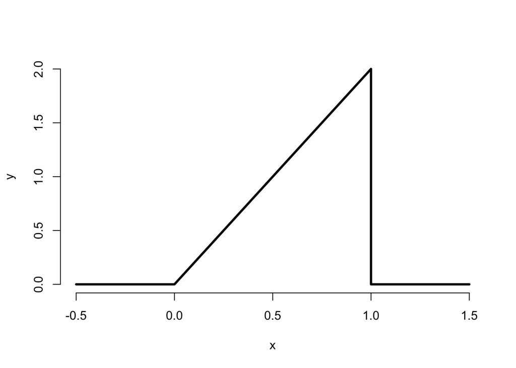

```r
x <- c(-0.5, 0, 1, 1, 1.5)
y <- c(0, 0, 2, 0, 0)
plot(x, y, lwd = 3, frame = FALSE, type = "l")
```

```r
# Valid?
(1*2)/2
```

```
## [1] 1
```

What is the probability that 75% of less calls are handled in one day?

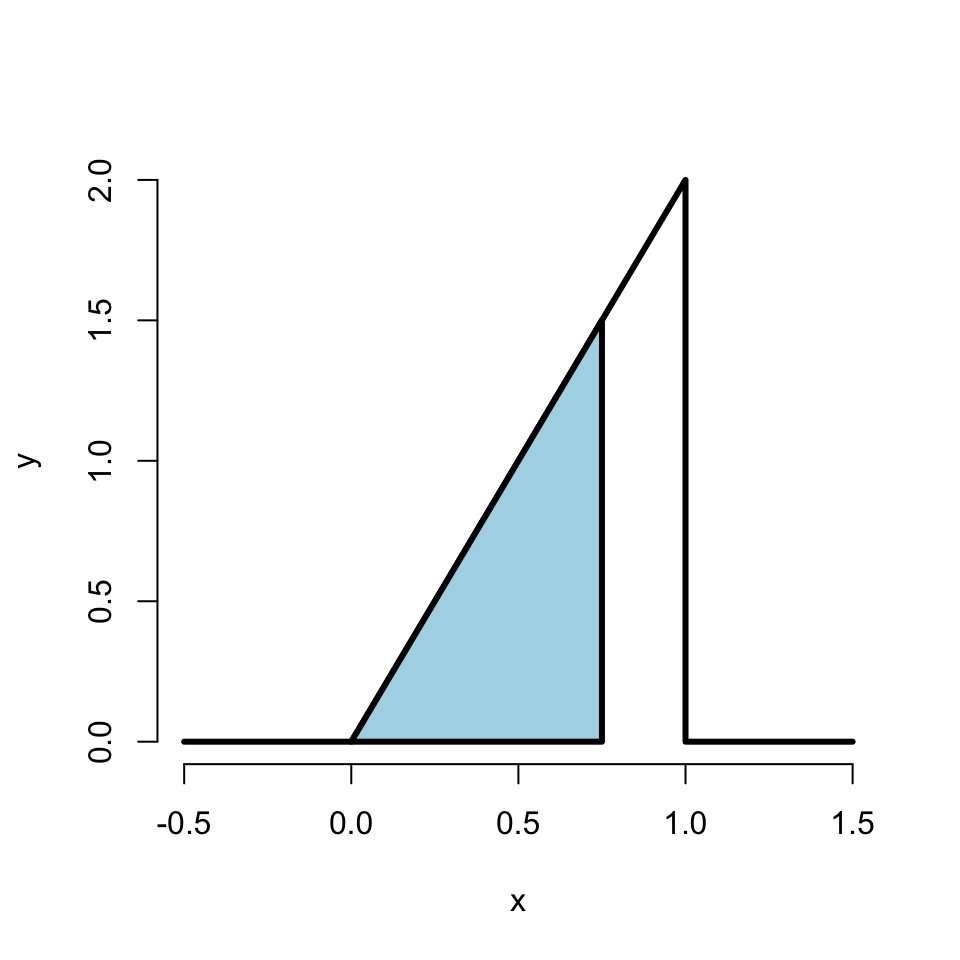

```r
(2*.75 * .75)/2
```

```
## [1] 0.5625
```

```r
pbeta(0.75, 2, 1)
```

```
## [1] 0.5625
```

## CDF and survival function

### Certain areas are so useful, we give them names

- The **cumulative distribution function** (CDF) of a random variable, $X$, returns the probability that the random variable is less than or equal to the value $x$ $F(x) = P(X \leq x)$

```r
# From the swirl work
# Get the CDF for a PDF of my creation (actually, theirs)
mypdf <- function(x){ x/2}
integrate(mypdf, lower=0, upper=1.6)
```

```
## 0.64 with absolute error < 7.1e-15
```

(This definition applies regardless of whether $X$ is discrete or continuous.) - The **survival function** of a random variable $X$ is defined as the probability that the random variable is greater than the value $x$ $S(x) = P(X > x)$ - Notice that $S(x) = 1 - F(x)$

```r
# Calculate the survival function for mypdf
integrate(mypdf, lower=1.6, upper=2)
```

```
## 0.36 with absolute error < 4e-15
```

## Example

What are the survival function and CDF from the density considered before?

For $1 \geq x \geq 0$ $F(x) = P(X \leq x) = \frac{1}{2} Base \times Height = \frac{1}{2} (x) \times (2 x) = x^2$

$S(x) = 1 - x^2$

```r
pbeta(c(0.4, 0.5, 0.6), 2, 1)
```

```
## [1] 0.16 0.25 0.36
```

## Quantiles

You’ve heard of sample quantiles. If you were the 95th percentile on an exam, you know that 95% of people scored worse than you and 5% scored better. These are sample quantities. Here we define their population analogs.

## For example

The $95^{th}$ percentile of a distribution is the point so that: - the probability that a random variable drawn from the population is less is 95% - the probability that a random variable drawn from the population is more is 5%

## Example continued

R can approximate quantiles for you for common distributions

```r
qbeta(0.5, 2, 1)
```

```
## [1] 0.7071068
```

## Summary

- You might be wondering at this point “I’ve heard of a median before, it didn’t require integration. Where’s the data?”
- We’re referring to are **population quantities**. Therefore, the median being discussed is the **population median**.
- A probability model connects the data to the population using assumptions.
- Therefore the median we’re discussing is the **estimand**, the sample median will be the **estimator**

# 3- Conditional Probability

## Conditional probability, motivation

- The probability of getting a one when rolling a (standard) die is usually assumed to be one sixth
- Suppose you were given the extra information that the die roll was an odd number (hence 1, 3 or 5)
- *conditional on this new information*, the probability of a one is now one third
- Let $B$ be an event so that $P(B) > 0$
- Then the conditional probability of an event $A$ given that $B$ has occurred is $P(A ~|~ B) = \frac{P(A \cap B)}{P(B)}$
- Notice that if $A$ and $B$ are independent (defined later in the lecture), then $P(A ~|~ B) = \frac{P(A) P(B)}{P(B)} = P(A)$

## Example

- Consider our die roll example
- $B = \{1, 3, 5\}$
- $A = \{1\}$ $\begin{eqnarray*} P(\mbox{one given that roll is odd}) & = & P(A ~|~ B) \\ \\ & = & \frac{P(A \cap B)}{P(B)} \\ \\ & = & \frac{P(A)}{P(B)} \\ \\ & = & \frac{1/6}{3/6} = \frac{1}{3} \end{eqnarray*}$

# Bayes’ rule

Baye’s rule allows us to reverse the conditioning set provided that we know some marginal probabilities (Presbyterian Minister, Thomas Bayes) $P(B ~|~ A) = \frac{P(A ~|~ B) P(B)}{P(A ~|~ B) P(B) + P(A ~|~ B^c)P(B^c)}.$

## Diagnostic tests

- Let $+$ and $-$ be the events that the result of a diagnostic test is positive or negative respectively
- Let $D$ and $D^c$ be the event that the subject of the test has or does not have the disease respectively
- The **sensitivity** is the probability that the test is positive given that the subject actually has the disease, $P(+ ~|~ D)$
- The **specificity** is the probability that the test is negative given that the subject does not have the disease, $P(- ~|~ D^c)$

## More definitions

- The **positive predictive value** is the probability that the subject has the disease given that the test is positive, $P(D ~|~ +)$
- The **negative predictive value** is the probability that the subject does not have the disease given that the test is negative, $P(D^c ~|~ -)$
- The **prevalence of the disease** is the marginal probability of disease, $P(D)$
- The **diagnostic likelihood ratio of a positive test**, labeled $DLR_+$, is $P(+ ~|~ D) / P(+ ~|~ D^c)$, which is the $sensitivity / (1 - specificity)$
- The **diagnostic likelihood ratio of a negative test**, labeled $DLR_-$, is $P(- ~|~ D) / P(- ~|~ D^c)$, which is the $(1 - sensitivity) / specificity$

## Example

- A study comparing the efficacy of HIV tests, reports on an experiment which concluded that HIV antibody tests have a sensitivity of 99.7% and a specificity of 98.5% (*Made up numbers*)
- Suppose that a subject, from a population with a .1% prevalence of HIV, receives a positive test result. What is the positive predictive value?
- Mathematically, we want $P(D ~|~ +)$ given the sensitivity, $P(+ ~|~ D) = .997$, the specificity, $P(- ~|~ D^c) =.985$, and the prevalence $P(D) = .001$

## Using Bayes’ formula

$\begin{eqnarray*} P(D ~|~ +) & = &\frac{P(+~|~D)P(D)}{P(+~|~D)P(D) + P(+~|~D^c)P(D^c)}\\ \\ & = & \frac{P(+~|~D)P(D)}{P(+~|~D)P(D) + \{1-P(-~|~D^c)\}\{1 - P(D)\}} \\ \\ & = & \frac{.997\times .001}{.997 \times .001 + .015 \times .999}\\ \\ & = & .062 \end{eqnarray*}$

```r
(.997*.001)/(.997 * .001 + (1-.985)*(1-.001))
```

```
## [1] 0.06238268
```

- In this population a positive test result only suggests a 6% probability that the subject has the disease
- (The positive predictive value is 6% for this test)

## More on this example

- The low positive predictive value is due to low prevalence of disease and the somewhat modest specificity
- Suppose it was known that the subject was an intravenous drug user and routinely had intercourse with an HIV infected partner
- Notice that the evidence implied by a positive test result does not change because of the prevalence of disease in the subject’s population, only our interpretation of that evidence changes

## Likelihood ratios

- Using Bayes rule, we have $P(D ~|~ +) = \frac{P(+~|~D)P(D)}{P(+~|~D)P(D) + P(+~|~D^c)P(D^c)}$ and $P(D^c ~|~ +) = \frac{P(+~|~D^c)P(D^c)}{P(+~|~D)P(D) + P(+~|~D^c)P(D^c)}.$

## Likelihood ratios

- Therefore $\frac{P(D ~|~ +)}{P(D^c ~|~ +)} = \frac{P(+~|~D)}{P(+~|~D^c)}\times \frac{P(D)}{P(D^c)}$ ie $\mbox{post-test odds of }D = DLR_+\times\mbox{pre-test odds of }D$
- Similarly, $DLR_-$ relates the decrease in the odds of the disease after a negative test result to the odds of disease prior to the test.

## HIV example revisited

- Suppose a subject has a positive HIV test
- $DLR_+ = .997 / (1 - .985) \approx 66$
- The result of the positive test is that the odds of disease is now 66 times the pretest odds
- Or, equivalently, the hypothesis of disease is 66 times more supported by the data than the hypothesis of no disease

## HIV example revisited

- Suppose that a subject has a negative test result
- $DLR_- = (1 - .997) / .985 \approx .003$
- Therefore, the post-test odds of disease is now $.3\%$ of the pretest odds given the negative test.
- Or, the hypothesis of disease is supported $.003$ times that of the hypothesis of absence of disease given the negative test result

# Independence

- Two events $A$ and $B$ are **independent** if $P(A \cap B) = P(A)P(B)$
- Equivalently if $P(A ~|~ B) = P(A)$
- Two random variables, $X$ and $Y$ are independent if for any two sets $A$ and $B$ $P([X \in A] \cap [Y \in B]) = P(X\in A)P(Y\in B)$
- If $A$ is independent of $B$ then
- $A^c$ is independent of $B$
- $A$ is independent of $B^c$
- $A^c$ is independent of $B^c$

## Example

- What is the probability of getting two consecutive heads?
- $A = \{\mbox{Head on flip 1}\}$ ~ $P(A) = .5$
- $B = \{\mbox{Head on flip 2}\}$ ~ $P(B) = .5$
- $A \cap B = \{\mbox{Head on flips 1 and 2}\}$
- $P(A \cap B) = P(A)P(B) = .5 \times .5 = .25$

## Example

- Volume 309 of Science reports on a physician who was on trial for expert testimony in a criminal trial
- Based on an estimated prevalence of sudden infant death syndrome of $1$ out of $8,543$, the physician testified that that the probability of a mother having two children with SIDS was $\left(\frac{1}{8,543}\right)^2$
- The mother on trial was convicted of murder

## Example: continued

- Relevant to this discussion, the principal mistake was to *assume* that the events of having SIDs within a family are independent
- That is, $P(A_1 \cap A_2)$ is not necessarily equal to $P(A_1)P(A_2)$
- Biological processes that have a believed genetic or familiar environmental component, of course, tend to be dependent within families
- (There are many other statistical points of discussion for this case.)

## The population mean

- The **expected value** or **mean** of a random variable is the center of its distribution
- For discrete random variable $X$ with PMF $p(x)$, it is defined as follows $E[X] = \sum_x xp(x).$ where the sum is taken over the possible values of $x$
- $E[X]$ represents the center of mass of a collection of locations and weights, $\{x, p(x)\}$

## Example

### Find the center of mass of the bars

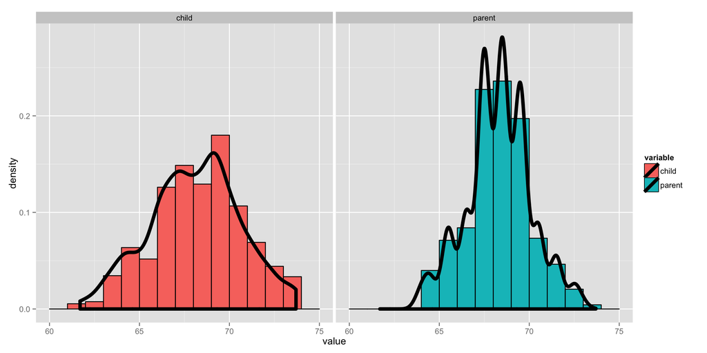

## The center of mass is the empirical mean

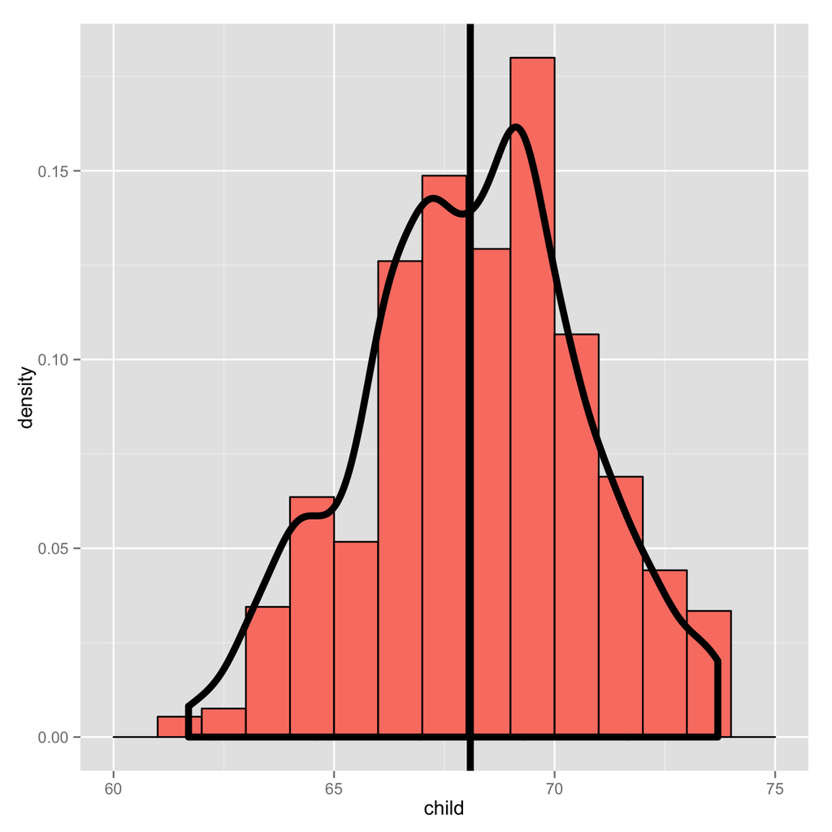

## What about a biased coin?

- Suppose that a random variable, $X$, is so that $P(X=1) = p$ and $P(X=0) = (1 - p)$
- (This is a biased coin when $p\neq 0.5$)
- What is its expected value? $E[X] = 0 * (1 - p) + 1 * p = p$

## Example

- Suppose that a die is rolled and $X$ is the number face up
- What is the expected value of $X$? $E[X] = 1 \times \frac{1}{6} + 2 \times \frac{1}{6} + 3 \times \frac{1}{6} + 4 \times \frac{1}{6} + 5 \times \frac{1}{6} + 6 \times \frac{1}{6} = 3.5$
- Again, the geometric argument makes this answer obvious without calculation.

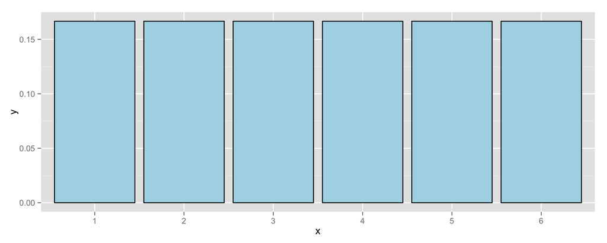

```r
expect_dice <- function(pmf) {
    mu <- 0
    for(i in 1:6) mu <- mu + i*pmf[i];
    mu
}
# dice_high, 6 rolls, E = 4.333
dice_high <- c(0.04761905, 0.09523810, 0.14285714, 0.19047619, 0.23809524, 0.28571429)
edh <- expect_dice(dice_high)
# dice_low, 6 rolls, E = 2.667
dice_low <- rev(dice_high)
edl <- expect_dice(dice_low)
edh + edl
```

```
## [1] 7
```

## Continuous random variables

- For a continuous random variable, $X$, with density, $f$, the expected value is again exactly the center of mass of the density

## Example

- Consider a density where $f(x) = 1$ for $x$ between zero and one
- (Is this a valid density?)
- Suppose that $X$ follows this density; what is its expected value?

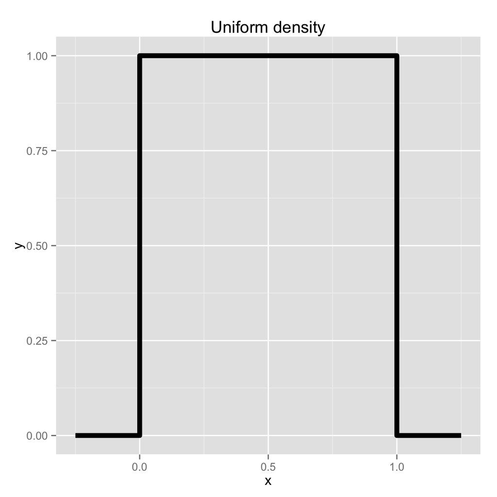

```r
# mean(Mean of 2 samples) = mean(original set)
spop <- c(1, 4, 7, 10, 13)
allsam <- t(combn(spop, 2))
smeans <- apply(allsam, 1, mean)
mean(smeans)
```

```
## [1] 7
```

## Facts about expected values

- Recall that expected values are properties of distributions
- Note the average of random variables is itself a random variable and its associated distribution has an expected value
- The center of this distribution is the same as that of the original distribution
- Therefore, the expected value of the **sample mean** is the population mean that it’s trying to estimate
- When the expected value of an estimator is what its trying to estimate, we say that the estimator is **unbiased**
- Let’s try a simulation experiment

## Averages of x die rolls

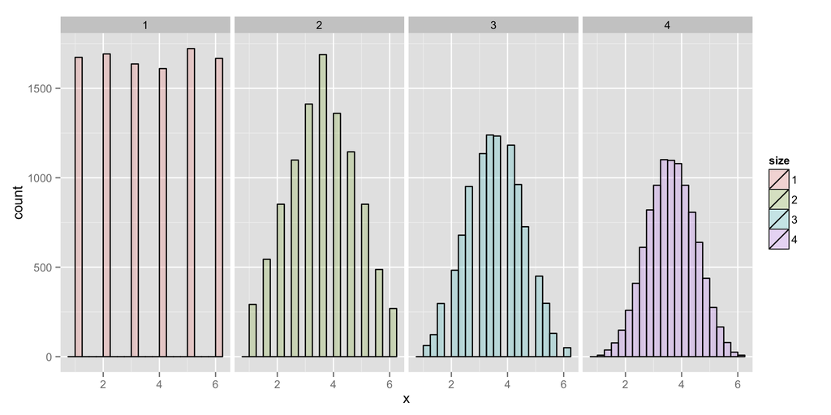

## Sumarizing what we know

- Expected values are properties of distributions
- The population mean is the center of mass of population
- The sample mean is the center of mass of the observed data
- The sample mean is an estimate of the population mean
- The sample mean is unbiased
- The population mean of its distribution is the mean that it’s trying to estimate
- The more data that goes into the sample mean, the more concentrated its density / mass function is around the population mean